# Problem Set 7

Author

Demonstration

The preferred format would be to do your work in a code chunk at the end of this document after the instructions. Use echo=TRUE for your code chunk so that your code is visible.

Do not alter the top lines between — and — except to *carefully* add your name inside the quotes.

Using your project data set, or any built in R dataset, do the following:

1. Using your chosen y (dependent) variable and one of your chosen x (explanatory) variables, perform a simple OLS regression using R. Follow these steps:

A. Load your data into a dataframe object

B. define a model object using the lm() function

```
- The format is `model <- lm(y ~ x, data = dataframe)`
- where:
- y is the dependent variable name from your dataframe
- x is the explanatory variable name from your dataframe
- and dataframe is the name of your dataframe object
```

C. report the model statistics using the summary() function

```
- The format is `summary(model)`
```

D. produce a model table using the stargazer() function from the stargazer library with type = “text”

```
- The format is `stargazer(model, type = "text")`
```

2. Using the same variables, produce a scatterplot with an lm() line and 95% confidence interval. You may use the base r plot() function or the ggplot() function from Lecture 15.

Load the data:

```r
#load demonstration_data.csv - you will use your own data and assign your own dataframe name
demonstration_data <- read.csv("demonstration_data.csv")
head(demonstration_data)
```

```
     X country_name country_text_id country_id v2x_delibdem v2x_egaldem
1  230       Mexico             MEX          3        0.467       0.375
2  353     Suriname             SUR          4        0.625       0.564
3  587       Sweden             SWE          5        0.872       0.836
4  812  Switzerland             CHE          6        0.880       0.839
5  933        Ghana             GHA          7        0.634       0.549
6 1056 South Africa             ZAF          8        0.633       0.472
  v2x_libdem v2x_partipdem v2x_polyarchy v2xcl_prpty v2clprptyw v2clprptym
1      0.448         0.426         0.671       0.818      1.539      1.667
2      0.624         0.484         0.764       0.855      1.817      1.802
3      0.885         0.659         0.916       0.941      2.336      2.716
4      0.872         0.812         0.910       0.938      2.613      2.308
5      0.630         0.387         0.739       0.868      1.819      1.966
6      0.620         0.480         0.731       0.757      1.077      1.531
  v2exl_legitideol v2exl_legitlead v2clacjstm v2clacjstw
1           -0.514          -0.430     -0.522     -0.397
2            0.003           0.790      1.296      1.331
3           -1.803          -2.937      2.706      3.069
4           -2.884          -2.135      3.238      3.428
5           -1.343          -0.864      2.062      1.727
6            0.058          -0.063      1.821      1.676
```

Define the model object using the lm function:

```r
#define model object using lm()
model_object1 <- lm(v2clacjstw ~ v2x_partipdem, data = demonstration_data)
```

Report the model statistics using the summary() function:

```r
#report model statistics using summary()

summary(model_object1)
```

```
Call:
lm(formula = v2clacjstw ~ v2x_partipdem, data = demonstration_data)

Residuals:
     Min       1Q   Median       3Q      Max
-1.88421 -0.46489 -0.00871  0.51419  3.11145

Coefficients:
              Estimate Std. Error t value Pr(>|t|)
(Intercept)    -0.9201     0.1188  -7.746 7.05e-13 ***
v2x_partipdem   5.1668     0.3036  17.016  < 2e-16 ***
---
Signif. codes:  0 '***' 0.001 '**' 0.01 '*' 0.05 '.' 0.1 ' ' 1

Residual standard error: 0.8031 on 177 degrees of freedom
Multiple R-squared:  0.6206,    Adjusted R-squared:  0.6185
F-statistic: 289.6 on 1 and 177 DF,  p-value: < 2.2e-16
```

Produce a model table using the stargazer() function from the stargazer library with type = “text”:

```r
# produce a model table using stargazer()
#first it is necessary to load the stargazer package with the library command
#install.packages("stargazer") # If you have not previously installed stargazer, you will need to do this first

library(stargazer)
stargazer(model_object1, type = "text")
```

```
===============================================
                        Dependent variable:
                    ---------------------------
                            v2clacjstw
-----------------------------------------------
v2x_partipdem                5.167***
                              (0.304)

Constant                     -0.920***
                              (0.119)

-----------------------------------------------
Observations                    179
R2                             0.621
Adjusted R2                    0.618
Residual Std. Error      0.803 (df = 177)
F Statistic          289.555*** (df = 1; 177)
===============================================
Note:               *p<0.1; **p<0.05; ***p<0.01
```

## Not from Problem Set but important

What is the equation for the regression line?

From the stargazer table:

Constant or alpha is -0.920

The coefficient for X (v2x_partipdem) is 5.167

*so the equation is*

v2clacjstw = -0.920 + 5.167* v2x_partipdem + error

Are the results significant?

The coefficient of v2x_partipdem is 5.167 and the standard error is 0.304. The t-value is 17.016. The p-value is < .05. The coefficient is significant at the 95% confidence level.

The Constant is also significant.

Use the ggplot function to produce a scatter plot with an lm() line and 95% confidence interval for the variables from the model object:

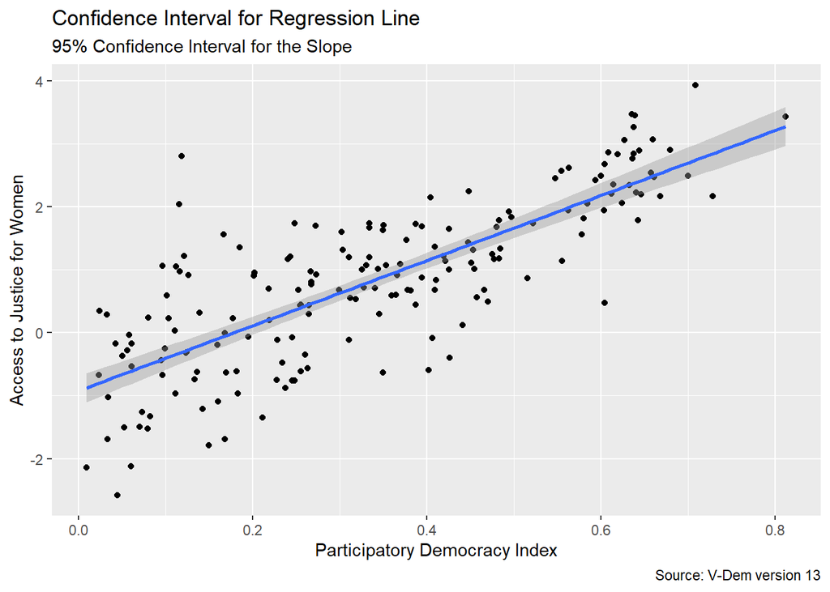

```r
# first need to load ggplot2 library
#install.packages("ggplot2") # If you have not previously installed ggplot2, you will need to do this first
library(ggplot2)


ggplot(data = demonstration_data, aes(x = v2x_partipdem, y = v2clacjstw)) +
  geom_point() +
  geom_smooth(method = "lm", se = TRUE) +
  labs(title = "Confidence Interval for Regression Line",
       subtitle = "95% Confidence Interval for the Slope",
       caption = "Source: V-Dem version 13") +
        xlab("Participatory Democracy Index") +
        ylab("Access to Justice for Women")
```